# Lab 9

Griffin Shelor

11/02/2023

# Areal Analysis Problem

The city of Chicago posts publicly available data on crime within the area as point based data. They also post data on the precincts and wards located within the city in which the crime data are reported. However, the precincts for the crime data are not reported, and so the common level of organization between the two data sets is “Ward”. Census data are also collected, where many demographics are reported, including Median Household income, which is often used as a predictor for crime rates.

Data sources are here https://data.cityofchicago.org/

Your job is to analyze the crimes reported as “burglaries” as a function of the Median Household Income aggregated by Ward.

## Question 1. 5pts

From the Chicago data folder, read in the census income data, and the precinct data, and aggregate the income data up to wards such that you have the area averaged median household income by ward.

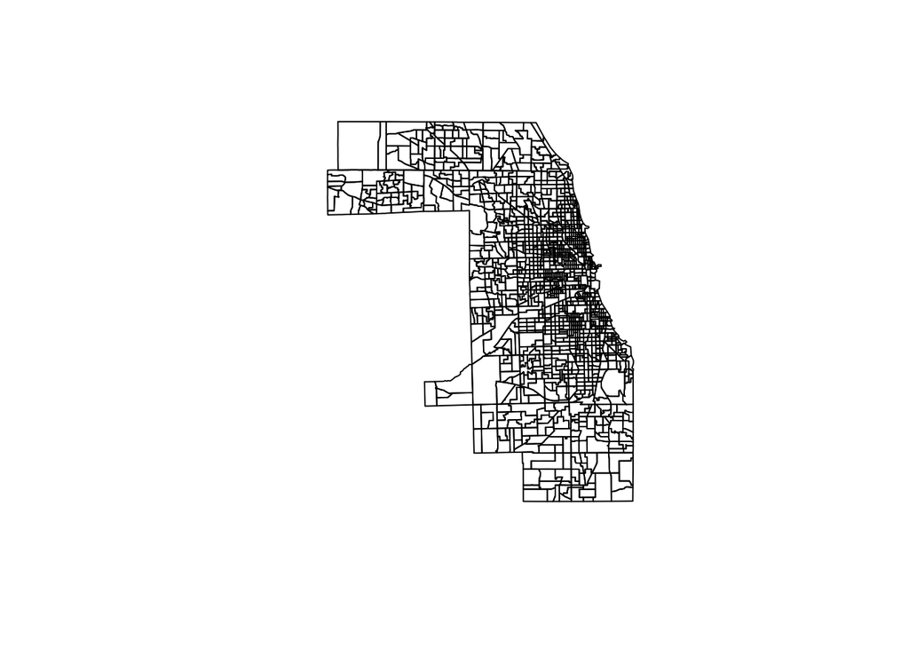

```r
income_sf <- read_sf("Chicago/Income.gpkg")
precincts_wards_sf <- read_sf("Chicago/Precincts/PecinctsAndWards.shp")
precincts_wards_sf <- st_transform(precincts_wards_sf, crs(income_sf))
plot(st_geometry(income_sf))
```

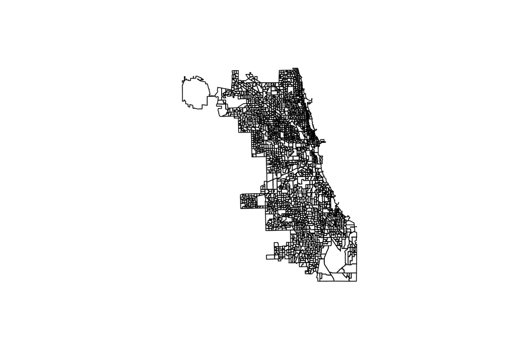

```r
plot(st_geometry(precincts_wards_sf))
```

```r
## Aggregating income data
precincts_wards_sf_2 <- summarise(group_by(precincts_wards_sf, ward))
joined_income_wards_sf <- sf::st_interpolate_aw(income_sf[,'MedHshldIncome'], precincts_wards_sf_2[,'ward'], extensive = F)
```

```r
joined_income_wards_sf$Ward <- seq(1:50)
# plot(joined_income_wards_sf)
```

## Question 2. 5pts

Now that you have the income data aggregated by ward read in the 2019 crime data calculate the number of burglaries per ward. Make a scatter plot of the number of burglaries vs Median household income.

```r
crime <- read_csv("Chicago/Crimes_-_2019.csv") |>
  drop_na()
```

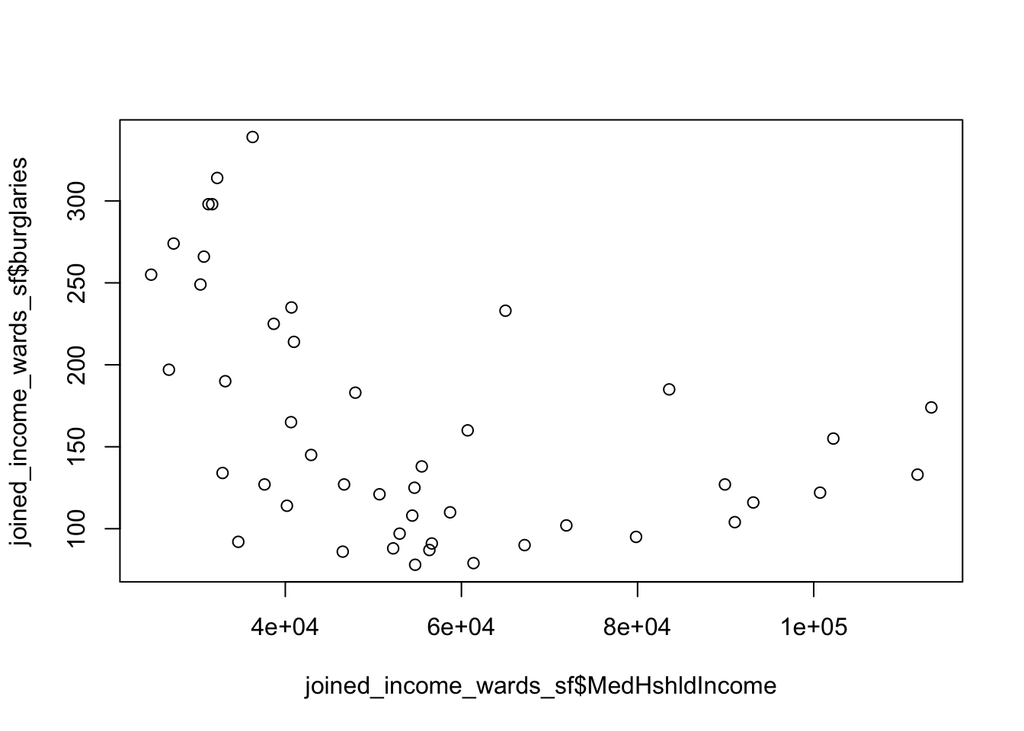

```r
crime_sf <- st_as_sf(crime, coords = c("Longitude", "Latitude"), crs = crs(income_sf))

# plot(st_geometry(joined_income_wards_sf))
# plot(crime_sf, add = TRUE)

joined_income_wards_sf$burglaries <- as.numeric(table(crime_sf[crime_sf$`Primary Type` == "BURGLARY",]$Ward))
joined_income_wards_sf <- joined_income_wards_sf |>
  drop_na()

plot(joined_income_wards_sf$MedHshldIncome, joined_income_wards_sf$burglaries)
```

## Question 3. -3pts

From the plot you made in the previous question it appears that there may be a relationship between the number of burglaries and household income. a) Create a non spatial linear model of these two variables and summarize the linear model. b) Is there a significant relationship between these two variables? c) Explain how you know.

```r
burglaries_income_lm <- lm(burglaries ~ MedHshldIncome, data = joined_income_wards_sf)
summary(burglaries_income_lm)
```

```
##
## Call:
## lm(formula = burglaries ~ MedHshldIncome, data = joined_income_wards_sf)
##
## Residuals:
##     Min      1Q  Median      3Q     Max
## -97.246 -55.410  -6.211  53.507 151.932
##
## Coefficients:
##                  Estimate Std. Error t value Pr(>|t|)
## (Intercept)     2.358e+02  2.437e+01   9.674 1.84e-12 ***
## MedHshldIncome -1.342e-03  4.065e-04  -3.301  0.00192 **
## ---
## Signif. codes:  0 '***' 0.001 '**' 0.01 '*' 0.05 '.' 0.1 ' ' 1
##
## Residual standard error: 65.25 on 44 degrees of freedom
## Multiple R-squared:  0.1985, Adjusted R-squared:  0.1803
## F-statistic:  10.9 on 1 and 44 DF,  p-value: 0.001917
```

```r
## There is a statistically significant relationship between median household income and the number of burglaries in a ward. We can tell because the p-value for the MedHshldIncome coefficient is well below 0.05. This indicates a reasonably high level of significance.
```

## Question 4. -3pts

Since you are analyzing aggregate data you are concerned that there may be spatial autocorrelation to be concerned with in your analysis. a) Create a neighborhood object allowing for up to 6 nearest neighbors, and b) plot your neighbor object over the wars polygon that you created in Question 2. c) Assign weights to your neighborhood object using three methods ‘W’, ‘B’, and ‘B’ with idw (note use 1/(x*100) as your idw function).

```r
set.seed(802)
burglary_wards_neighbors <- knn2nb(knearneigh(st_centroid(joined_income_wards_sf), k = 6))
centercoords <- st_coordinates(st_centroid(joined_income_wards_sf))
```

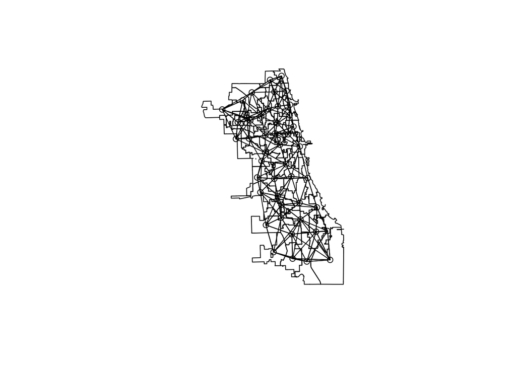

```r
plot(st_geometry(joined_income_wards_sf))
plot(burglary_wards_neighbors, centercoords, add = T)
```

```r
dsts <- nbdists(burglary_wards_neighbors, st_geometry(st_centroid(joined_income_wards_sf)))
idw <- lapply(dsts, function(x) 1/(x*100))
burglary_lw_B <- nb2listw(burglary_wards_neighbors, style = "B")
burglary_lw_idwB <- nb2listw(burglary_wards_neighbors, glist = idw, style = "B")
burglary_lw_W <- nb2listw(burglary_wards_neighbors, style = "W")
#NY8_lw_idwB <- nb2listw(NY_nb, glist = idw, style = "B")
summary(unlist(burglary_lw_idwB$weights))
```

```
##     Min.  1st Qu.   Median     Mean  3rd Qu.     Max.
## 0.001021 0.002092 0.002592 0.002832 0.003119 0.011421
```

```r
summary(unlist(burglary_lw_B$weights))
```

```
##    Min. 1st Qu.  Median    Mean 3rd Qu.    Max.
##       1       1       1       1       1       1
```

```r
summary(unlist(burglary_lw_W$weights))
```

```
##    Min. 1st Qu.  Median    Mean 3rd Qu.    Max.
##  0.1667  0.1667  0.1667  0.1667  0.1667  0.1667
```

## Question 5. -4pts

Test whether your data are spatially autocorrelated using Moran’s I test. Show your work. a) Are they spatially autocorrelated? b) How do you know? c) Do any of the weighting schemes correct for this?

```r
# moran.test(joined_income_wards_sf$burglaries, listw = burglary_lw_W)
# moran.test(joined_income_wards_sf$burglaries, listw = burglary_lw_idwB)
# moran.test(joined_income_wards_sf$burglaries, listw = burglary_lw_B)
mantel_idwB <- sp.mantel.mc(joined_income_wards_sf$burglaries, type = 'moran', listw = burglary_lw_idwB, nsim=100)
mantel_B <- sp.mantel.mc(joined_income_wards_sf$burglaries, type = 'moran', listw = burglary_lw_B, nsim=100)
mantel_W <- sp.mantel.mc(joined_income_wards_sf$burglaries, type = 'moran', listw = burglary_lw_W, nsim=100)
mantel_idwB
```

```
##
##  Mantel permutation test for moran measure
##
## data:  joined_income_wards_sf$burglaries
## weights: burglary_lw_idwB
## number of simulations + 1: 101
##
## statistic = 0.40082, observed rank = 101, p-value = 0.009901
## alternative hypothesis: greater
## sample estimates:
## mean of permutations   sd of permutations
##          -0.02430000           0.05855521
```

```r
mantel_B
```

```
##
##  Mantel permutation test for moran measure
##
## data:  joined_income_wards_sf$burglaries
## weights: burglary_lw_B
## number of simulations + 1: 101
##
## statistic = 126.12, observed rank = 101, p-value = 0.009901
## alternative hypothesis: greater
## sample estimates:
## mean of permutations   sd of permutations
##            -3.336162            19.274531
```

```r
mantel_W
```

```
##
##  Mantel permutation test for moran measure
##
## data:  joined_income_wards_sf$burglaries
## weights: burglary_lw_W
## number of simulations + 1: 101
##
## statistic = 21.02, observed rank = 101, p-value = 0.009901
## alternative hypothesis: greater
## sample estimates:
## mean of permutations   sd of permutations
##            -1.000077             3.420063
```

```r
## The data do appear to be spatially autocorrelated. This is indicated by the low p-values, which are below 0.05 for all of the moran tests. The weighting schemes do not correct for this, since Moran's I cannot always be trusted if there is a hidden confounding variable which may explain the appearance of spatial autocorrelation.
```

## Question 6. -7pts

Create spatial linear models of your data (all three weighting schemes using both the a) SAR and b) CAR modeling families. c) Do all of the models show the same general trend? d) what is it? e) use AIC to find the best performing model. Which model is it? f) create a spatial plot of your best model with the predicted burglaries given household income symbolized across your ward polygons.

```r
## SAR models
burglary_splm_idwB_SAR <- spautolm(burglaries ~ MedHshldIncome, data=joined_income_wards_sf, listw=burglary_lw_idwB)
summary(burglary_splm_idwB_SAR)
```

```
##
## Call:
## spautolm(formula = burglaries ~ MedHshldIncome, data = joined_income_wards_sf,
##     listw = burglary_lw_idwB)
##
## Residuals:
##       Min        1Q    Median        3Q       Max
## -121.0718  -28.5510   -1.1782   26.2213  121.0605
##
## Coefficients:
##                   Estimate  Std. Error z value  Pr(>|z|)
## (Intercept)     2.2397e+02  3.0345e+01  7.3807 1.574e-13
## MedHshldIncome -1.2940e-03  4.5004e-04 -2.8753  0.004036
##
## Lambda: 40.43 LR test value: 22.024 p-value: 2.6922e-06
## Numerical Hessian standard error of lambda: 5.414
##
## Log likelihood: -245.4338
## ML residual variance (sigma squared): 2185.6, (sigma: 46.75)
## Number of observations: 46
## Number of parameters estimated: 4
## AIC: NA (not available for weighted model)
```

```r
burglary_splm_B_SAR <- spautolm(burglaries ~ MedHshldIncome, data=joined_income_wards_sf, listw=burglary_lw_B)
summary(burglary_splm_B_SAR)
```

```
##
## Call:
## spautolm(formula = burglaries ~ MedHshldIncome, data = joined_income_wards_sf,
##     listw = burglary_lw_B)
##
## Residuals:
##       Min        1Q    Median        3Q       Max
## -149.6476  -30.9792    2.3639   27.1561  126.2319
##
## Coefficients:
##                   Estimate  Std. Error z value  Pr(>|z|)
## (Intercept)     2.1762e+02  3.5674e+01  6.1003 1.059e-09
## MedHshldIncome -1.2973e-03  4.5679e-04 -2.8399  0.004513
##
## Lambda: 0.11718 LR test value: 16.954 p-value: 3.8288e-05
## Numerical Hessian standard error of lambda: 0.021865
##
## Log likelihood: -247.9688
## ML residual variance (sigma squared): 2548.6, (sigma: 50.484)
## Number of observations: 46
## Number of parameters estimated: 4
## AIC: NA (not available for weighted model)
```

```r
burglary_splm_W_SAR <- spautolm(burglaries ~ MedHshldIncome, data=joined_income_wards_sf, listw=burglary_lw_W)
summary(burglary_splm_W_SAR)
```

```
##
## Call:
## spautolm(formula = burglaries ~ MedHshldIncome, data = joined_income_wards_sf,
##     listw = burglary_lw_W)
##
## Residuals:
##       Min        1Q    Median        3Q       Max
## -149.6476  -30.9792    2.3639   27.1561  126.2319
##
## Coefficients:
##                   Estimate  Std. Error z value  Pr(>|z|)
## (Intercept)     2.1762e+02  3.5674e+01  6.1003 1.059e-09
## MedHshldIncome -1.2973e-03  4.5679e-04 -2.8399  0.004513
##
## Lambda: 0.7031 LR test value: 16.954 p-value: 3.8288e-05
## Numerical Hessian standard error of lambda: 0.13119
##
## Log likelihood: -247.9688
## ML residual variance (sigma squared): 2548.6, (sigma: 50.484)
## Number of observations: 46
## Number of parameters estimated: 4
## AIC: NA (not available for weighted model)
```

```r
## CAR Models
burglary_splm_idwB_CAR <- spautolm(burglaries ~ MedHshldIncome, data=joined_income_wards_sf, family = "CAR", listw=burglary_lw_idwB)
summary(burglary_splm_idwB_CAR)
```

```
##
## Call:
## spautolm(formula = burglaries ~ MedHshldIncome, data = joined_income_wards_sf,
##     listw = burglary_lw_idwB, family = "CAR")
##
## Residuals:
##        Min         1Q     Median         3Q        Max
## -126.27555  -27.68279   -0.94194   24.25786  115.48461
##
## Coefficients:
##                   Estimate  Std. Error z value Pr(>|z|)
## (Intercept)     2.2716e+02  2.7006e+01  8.4114  < 2e-16
## MedHshldIncome -1.3379e-03  4.4679e-04 -2.9943  0.00275
##
## Lambda: 45.459 LR test value: 17.074 p-value: 3.5958e-05
## Numerical Hessian standard error of lambda: 3.2683
##
## Log likelihood: -247.9092
## ML residual variance (sigma squared): 2507.2, (sigma: 50.072)
## Number of observations: 46
## Number of parameters estimated: 4
## AIC: NA (not available for weighted model)
```

```r
burglary_splm_B_CAR <- spautolm(burglaries ~ MedHshldIncome, data=joined_income_wards_sf, family = "CAR", listw=burglary_lw_B)
summary(burglary_splm_B_CAR)
```

```
##
## Call:
## spautolm(formula = burglaries ~ MedHshldIncome, data = joined_income_wards_sf,
##     listw = burglary_lw_B, family = "CAR")
##
## Residuals:
##      Min       1Q   Median       3Q      Max
## -165.547  -25.115   -2.983   31.776  118.339
##
## Coefficients:
##                   Estimate  Std. Error z value  Pr(>|z|)
## (Intercept)     1.5026e+02  3.6480e+01  4.1191 3.804e-05
## MedHshldIncome -1.1967e-03  4.5425e-04 -2.6344  0.008429
##
## Lambda: 0.15307 LR test value: 16.066 p-value: 6.1184e-05
## Numerical Hessian standard error of lambda: NaN
##
## Log likelihood: -248.4132
## ML residual variance (sigma squared): 2548.3, (sigma: 50.48)
## Number of observations: 46
## Number of parameters estimated: 4
## AIC: NA (not available for weighted model)
```

```r
burglary_splm_W_CAR <- spautolm(burglaries ~ MedHshldIncome, data=joined_income_wards_sf, family = "CAR", listw=burglary_lw_W)
summary(burglary_splm_W_CAR)
```

```
##
## Call:
## spautolm(formula = burglaries ~ MedHshldIncome, data = joined_income_wards_sf,
##     listw = burglary_lw_W, family = "CAR")
##
## Residuals:
##      Min       1Q   Median       3Q      Max
## -165.547  -25.115   -2.983   31.776  118.339
##
## Coefficients:
##                   Estimate  Std. Error z value  Pr(>|z|)
## (Intercept)     1.5026e+02  3.6480e+01  4.1191 3.804e-05
## MedHshldIncome -1.1967e-03  4.5425e-04 -2.6344  0.008429
##
## Lambda: 0.91842 LR test value: 16.066 p-value: 6.1184e-05
## Numerical Hessian standard error of lambda: NaN
##
## Log likelihood: -248.4132
## ML residual variance (sigma squared): 2548.3, (sigma: 50.48)
## Number of observations: 46
## Number of parameters estimated: 4
## AIC: NA (not available for weighted model)
```

```r
## Yes, all of the models do show the same general trend, with the p-values all displaying significance and the parameter estimate for median household income being negative and relatively similar values for each model. Essentially, as median household income increased, burglaries in a ward decreases.

## AIC
burglary_mods <- ls(pattern='burglary_splm_')
myaic <- data.frame(model=NA, AIC=0, DAIC=0, LambdaP=0)
for(i in 1:length(burglary_mods)){
tmp <- summary(get(burglary_mods[i]))
myaic[i,1] <- burglary_mods[i]
myaic[i,2] <- AIC(get(burglary_mods[i]))
myaic[i,4] <- tmp$LR1$p.value[1][[1]]
}
myaic$DAIC <- myaic$AIC - min(myaic$AIC)
myaic <- myaic[order( myaic$AIC),]
myaic
```

```
##                    model      AIC     DAIC      LambdaP
## 4 burglary_splm_idwB_SAR 498.8677 0.000000 2.692202e-06
## 3 burglary_splm_idwB_CAR 503.8183 4.950643 3.595761e-05
## 2    burglary_splm_B_SAR 503.9375 5.069884 3.828812e-05
## 6    burglary_splm_W_SAR 503.9375 5.069884 3.828812e-05
## 1    burglary_splm_B_CAR 504.8263 5.958666 6.118431e-05
## 5    burglary_splm_W_CAR 504.8263 5.958666 6.118431e-05
```

```r
## My best model is the SAR model which included weights which included IDW in the weight assigning process.
```

## Plotting our trend

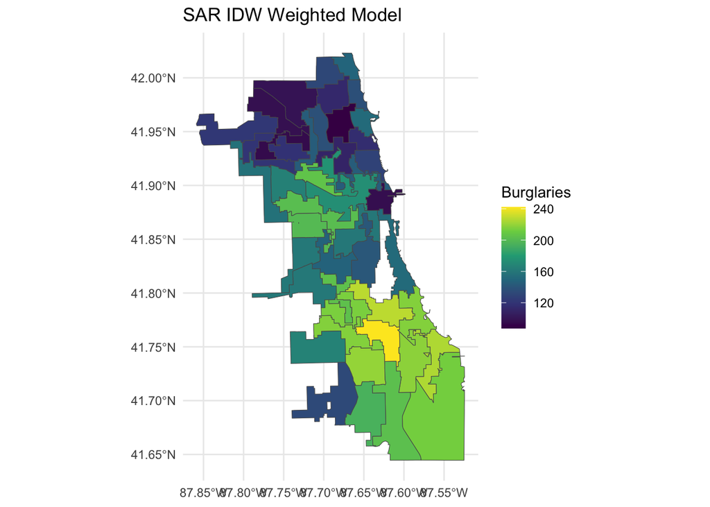

```r
joined_income_wards_sf$SAR_IDW_fitted <- burglary_splm_idwB_SAR$fit$fitted.values
burglary_trend_plot <- ggplot() +
  theme_minimal() +
  geom_sf(joined_income_wards_sf, mapping = aes(fill = SAR_IDW_fitted)) +
  scale_fill_viridis_c() +
  ggtitle('SAR IDW Weighted Model') +
  guides(fill = guide_colourbar(title = 'Burglaries'))
burglary_trend_plot
```